# regression-analysis.Rmd

Karim Qazi

October 26, 2014

**Executive Summary**

We are interested in exploring the relationship between a set of variables and miles per gallon (MPG) (outcome). This report attempts to answer the following questions as it relates to this high level goal:

1. Is an automatic or manual transmission better for MPG?
2. Quantify the MPG difference between automatic and manual transmissions?

We will use the “mtcars” data set to perform this analysis.

**Exploratory Data Analysis**

```r
avgTransMPG <- aggregate(x = mtcars$mpg, by=list(mtcars$am), mean)
colnames(avgTransMPG)[1:2] <- c("Transmission", "MPG")
```

[output not shown]

One thing to note is that when wanting to predict MPG from transmission type it does not look to be a good fit for a linear regression model. See **Figure 1** in the appendix for evidence of this.

That said when looking at weight we can see it looks to be a potentially better predictor of MPG than transmission type is. Weight is the estimated expected change in **mpg** per 1,000 lb increase in weight.

```r
avgWeightMPG <- aggregate(x = mtcars$mpg, by=list(round(mtcars$wt, 0)), mean)
colnames(avgWeightMPG)[1:2] <- c("Weight (in tons)", "MPG")
kable(avgWeightMPG)
```

```
##
##
## | Weight (in tons)|   MPG|
## |----------------:|-----:|
## |                2| 28.09|
## |                3| 19.73|
## |                4| 15.78|
## |                5| 11.83|
```

**Interpretation of Coefficents**

Looking at all the variables in the data set we can compare **mpg** to all the other potential predictors of **mpg**. Seeing that **am** (which indicates transmission) looks to predict ~**2.52** increase in **mpg** when comparing automatic vs. manual, whereas **weight** (wt) predicts a decrease of **~3.72** which looks to be a better predictor of **mpg**.

```r
summary(lm(mpg ~ . , data=mtcars))$coef
```

```
##             Estimate Std. Error t value Pr(>|t|)
## (Intercept) 12.30337   18.71788  0.6573  0.51812
## cyl         -0.11144    1.04502 -0.1066  0.91609
## disp         0.01334    0.01786  0.7468  0.46349
## hp          -0.02148    0.02177 -0.9868  0.33496
## drat         0.78711    1.63537  0.4813  0.63528
## wt          -3.71530    1.89441 -1.9612  0.06325
## qsec         0.82104    0.73084  1.1234  0.27394
## vs           0.31776    2.10451  0.1510  0.88142
## am           2.52023    2.05665  1.2254  0.23399
## gear         0.65541    1.49326  0.4389  0.66521
## carb        -0.19942    0.82875 -0.2406  0.81218
```

Also if we look at the “p-value” when using weight as a predictor of “mpg” we can see that it has a very low p-value of **1.293959e-10** which should indicate that weight has a very good probability of predicting “weight”.

```r
x <- mtcars$wt
y <- mtcars$mpg
n <- length(y)
fit <- lm(y ~ x)
summary(fit)$coef
```

```
##             Estimate Std. Error t value  Pr(>|t|)
## (Intercept)   37.285     1.8776  19.858 8.242e-19
## x             -5.344     0.5591  -9.559 1.294e-10
```

We can also see from **Figure 2** in the appendix that **weight** looks to predict **MPG** well from a linear regression standpoint.

```r
e <- resid(fit)
yhat <- predict(fit)
max(abs(e -(y - yhat)))
```

```
## [1] 7.239e-14
```

**Conclusion**

**Appendix**

**Figure 1**

Illustrates that using transmission type to predict MPG is a poor model fit.

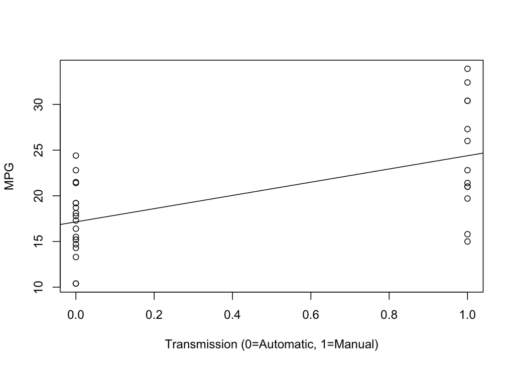

```r
plot(mtcars$am, mtcars$mpg, xlab="Transmission (0=Automatic, 1=Manual)", ylab="MPG")
abline(lm(mtcars$mpg ~ mtcars$am))
```

**Figure 2**

Linear fit of when using car weight to predict MPG.

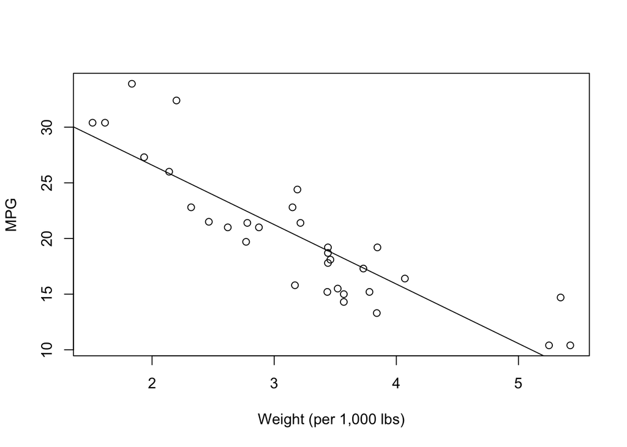

```r
plot(mtcars$wt, mtcars$mpg, xlab="Weight (per 1,000 lbs)", ylab="MPG")
abline(lm(mtcars$mpg ~ mtcars$wt))
```

**Figure 3**

Residual variation for linear model.

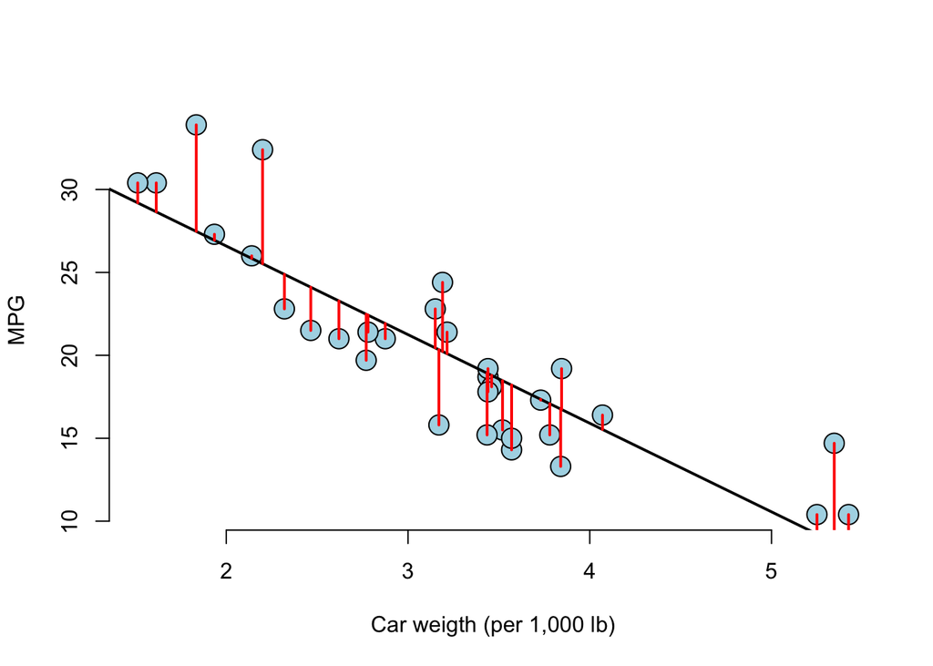

```r
plot(x, y,
     xlab = "Car weigth (per 1,000 lb)",
     ylab = "MPG",
     bg = "lightblue",
     col = "black", cex = 2, pch = 21,frame = FALSE)
abline(fit, lwd = 2)
for (i in 1 : n)
  lines(c(x[i], x[i]), c(y[i], yhat[i]), col = "red" , lwd = 2)
```